# Ozan Eroğlu IE 360- HW2

Adding corralated variables obsewrved with the ggpairs function model to investigate under t test.

```r
fit <- lm(Unleaded.Gasoline.Sale..UGS.~trend+as.factor(seasonality)+
+X..LPG.Vehicles..NLPG.
+X..Unleaded.Gasoline.Vehicles..NUGV., hwdata)
summary(fit)
```

```
##
## Call:
## lm(formula = Unleaded.Gasoline.Sale..UGS. ~ trend + as.factor(seasonality) +
##     +X..LPG.Vehicles..NLPG. + X..Unleaded.Gasoline.Vehicles..NUGV.,
##     data = hwdata)
##
## Residuals:
##    Min     1Q Median     3Q    Max
## -87817 -23021   3674  23544  84303
##
## Coefficients:
##                                        Estimate Std. Error t value Pr(>|t|)
## (Intercept)                           5.570e+05  4.911e+05   1.134 0.269486
## trend                                -2.607e+04  4.810e+03  -5.420 2.24e-05 ***
## as.factor(seasonality)2               1.281e+05  2.167e+04   5.911 7.23e-06 ***
## as.factor(seasonality)3               2.813e+05  2.188e+04  12.855 2.03e-11 ***
## as.factor(seasonality)4               9.594e+04  2.223e+04   4.316 0.000305 ***
## X..LPG.Vehicles..NLPG.                3.240e-01  9.348e-02   3.466 0.002311 **
## X..Unleaded.Gasoline.Vehicles..NUGV.  5.411e-02  1.046e-01   0.518 0.610172
## ---
## Signif. codes:  0 '***' 0.001 '**' 0.01 '*' 0.05 '.' 0.1 ' ' 1
##
## Residual standard error: 40280 on 21 degrees of freedom
##   (4 observations deleted due to missingness)
## Multiple R-squared:  0.9447, Adjusted R-squared:  0.9289
## F-statistic: 59.78 on 6 and 21 DF,  p-value: 4.085e-12
```

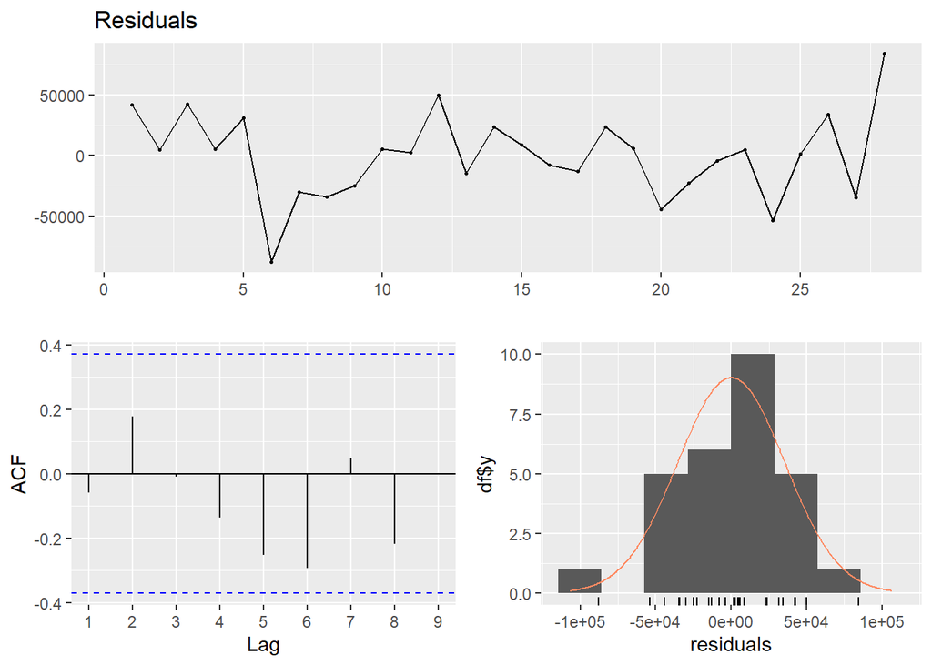

```
##
##  Breusch-Godfrey test for serial correlation of order up to 10
##
## data:  Residuals
## LM test = 15.02, df = 10, p-value = 0.1313
```

```r
checkresiduals(fit)
```

NUGV variable has non-significance as the T-Tes shows so I will drop the variable.

```r
fit <- lm(Unleaded.Gasoline.Sale..UGS.~trend+as.factor(seasonality)
+X..LPG.Vehicles..NLPG., data = hwdata)
summary(fit)
```

```
##
## Call:
## lm(formula = Unleaded.Gasoline.Sale..UGS. ~ trend + as.factor(seasonality) +
##     X..LPG.Vehicles..NLPG., data = hwdata)
##
## Residuals:
##    Min     1Q Median     3Q    Max
## -83022 -23287   3235  18555  90847
##
## Coefficients:
##                           Estimate Std. Error t value Pr(>|t|)
## (Intercept)              8.082e+05  7.363e+04  10.977 2.16e-10 ***
## trend                   -2.422e+04  3.163e+03  -7.657 1.21e-07 ***
## as.factor(seasonality)2  1.286e+05  2.128e+04   6.044 4.40e-06 ***
## as.factor(seasonality)3  2.824e+05  2.140e+04  13.200 6.24e-12 ***
## as.factor(seasonality)4  9.835e+04  2.137e+04   4.601 0.000139 ***
## X..LPG.Vehicles..NLPG.   3.259e-01  9.184e-02   3.549 0.001800 **
## ---
## Signif. codes:  0 '***' 0.001 '**' 0.01 '*' 0.05 '.' 0.1 ' ' 1
##
## Residual standard error: 39600 on 22 degrees of freedom
##   (4 observations deleted due to missingness)
## Multiple R-squared:  0.944,  Adjusted R-squared:  0.9313
## F-statistic: 74.15 on 5 and 22 DF,  p-value: 5.077e-13
```

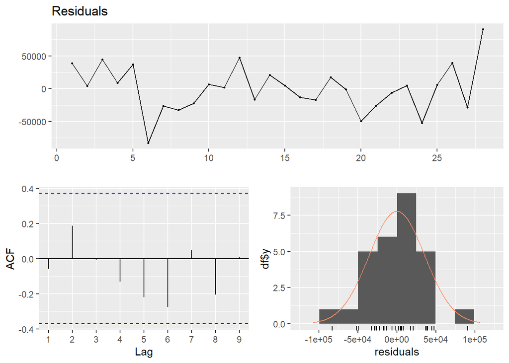

```
##
##  Breusch-Godfrey test for serial correlation of order up to 9
##
## data:  Residuals
## LM test = 13.521, df = 9, p-value = 0.1404
```

```r
checkresiduals(fit)
```

Adjusted r-square incresed due to drop off

```r
fit <- lm(Unleaded.Gasoline.Sale..UGS.~trend+as.factor(seasonality)+
+X..LPG.Vehicles..NLPG.+ ( X..of.Diesel.Gasoline.Vehicles..NDGV.)^2, data = hwdata)
summary(fit)
```

```
##
## Call:
## lm(formula = Unleaded.Gasoline.Sale..UGS. ~ trend + as.factor(seasonality) +
##     +X..LPG.Vehicles..NLPG. + (X..of.Diesel.Gasoline.Vehicles..NDGV.)^2,
##     data = hwdata)
##
## Residuals:
##    Min     1Q Median     3Q    Max
## -89809 -19510   2524  25147  70668
##
## Coefficients:
##                                         Estimate Std. Error t value Pr(>|t|)
## (Intercept)                            4.861e+05  2.550e+05   1.906 0.070408
## trend                                 -2.437e+04  3.114e+03  -7.828 1.17e-07
## as.factor(seasonality)2                1.266e+05  2.100e+04   6.030 5.53e-06
## as.factor(seasonality)3                2.794e+05  2.117e+04  13.199 1.23e-11
## as.factor(seasonality)4                9.519e+04  2.116e+04   4.498 0.000198
## X..LPG.Vehicles..NLPG.                 2.535e-01  1.058e-01   2.397 0.025917
## X..of.Diesel.Gasoline.Vehicles..NDGV.  1.393e+03  1.058e+03   1.317 0.202020
##
## (Intercept)                           .
## trend                                 ***
## as.factor(seasonality)2               ***
## as.factor(seasonality)3               ***
## as.factor(seasonality)4               ***
## X..LPG.Vehicles..NLPG.                *
## X..of.Diesel.Gasoline.Vehicles..NDGV.
## ---
## Signif. codes:  0 '***' 0.001 '**' 0.01 '*' 0.05 '.' 0.1 ' ' 1
##
## Residual standard error: 38960 on 21 degrees of freedom
##   (4 observations deleted due to missingness)
## Multiple R-squared:  0.9483, Adjusted R-squared:  0.9335
## F-statistic: 64.14 on 6 and 21 DF,  p-value: 2.042e-12
```

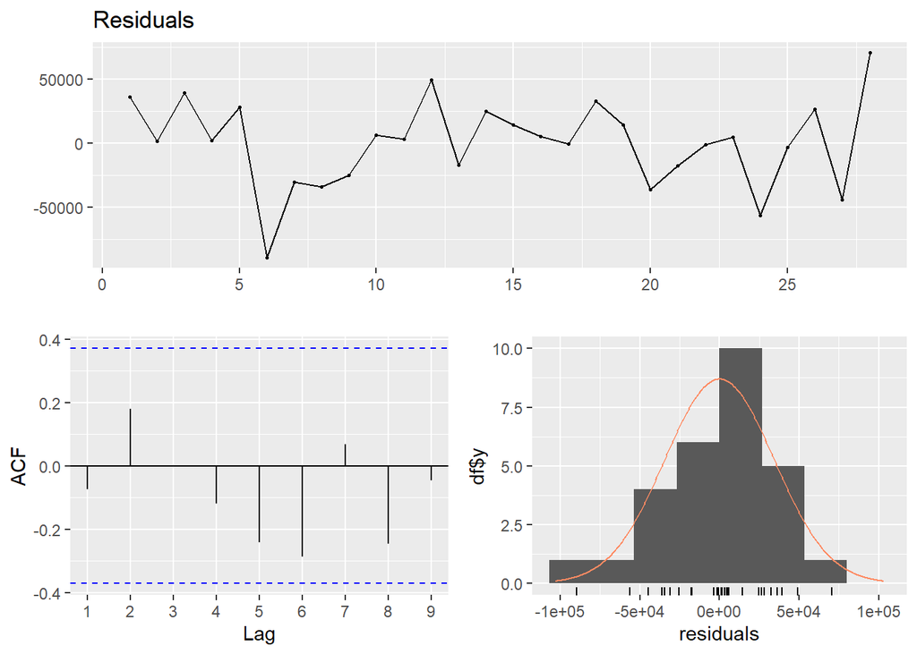

```
##
##  Breusch-Godfrey test for serial correlation of order up to 10
##
## data:  Residuals
## LM test = 15.953, df = 10, p-value = 0.101
```

```r
checkresiduals(fit)
```

```r
summary(hwdata)
```

```
##    Quarter          Unleaded.Gasoline.Sale..UGS.      RNUV
##  Length:32          Min.   : 736580              Min.   :0.001200
##  Class :character   1st Qu.: 876211              1st Qu.:0.004100
##  Mode  :character   Median : 983573              Median :0.007250
##                     Mean   : 987212              Mean   :0.008906
##                     3rd Qu.:1097324              3rd Qu.:0.013150
##                     Max.   :1370167              Max.   :0.020700
##                     NA's   :4
##  X..LPG.Vehicles..NLPG. Price.of.Unleaded.Gasoline..PU.
##  Min.   : 940000        Min.   :402.1
##  1st Qu.: 997500        1st Qu.:479.2
##  Median :1352000        Median :526.7
##  Mean   :1299922        Mean   :519.2
##  3rd Qu.:1602000        3rd Qu.:565.2
##  Max.   :1797400        Max.   :609.0
##
##  Price.of.Diesel.Gasoline..PG. X..Unleaded.Gasoline.Vehicles..NUGV.
##  Min.   :300.7                 Min.   :4647500
##  1st Qu.:366.9                 1st Qu.:5029281
##  Median :401.6                 Median :5186068
##  Mean   :400.4                 Mean   :5296758
##  3rd Qu.:449.2                 3rd Qu.:5604709
##  Max.   :471.9                 Max.   :6065597
##
##  X..of.Diesel.Gasoline.Vehicles..NDGV. GNP.Agriculture    GNP.Commerce
##  Min.   :282.0                         Min.   : 832953   Min.   :3374849
##  1st Qu.:286.6                         1st Qu.:1348066   1st Qu.:4403081
##  Median :291.9                         Median :1850657   Median :5124300
##  Mean   :304.9                         Mean   :2895561   Mean   :5246534
##  3rd Qu.:322.9                         3rd Qu.:3922950   3rd Qu.:5967433
##  Max.   :357.3                         Max.   :7140722   Max.   :7480414
##
##    GNP.Total            trend       seasonality two_lagged_sales
##  Min.   :15832648   Min.   : 1.00   1:8         Min.   : 736580
##  1st Qu.:21790148   1st Qu.: 8.75   2:8         1st Qu.: 876211
##  Median :25229712   Median :16.50   3:8         Median : 983573
##  Mean   :25745763   Mean   :16.50   4:8         Mean   : 987212
##  3rd Qu.:29843404   3rd Qu.:24.25               3rd Qu.:1097324
##  Max.   :36741745   Max.   :32.00               Max.   :1370167
##                                                 NA's   :4
```

```r
fit= lm(Unleaded.Gasoline.Sale..UGS.~trend + seasonality
            + Price.of.Diesel.Gasoline..PG.+two_lagged_sales, hwdata)
summary(fit)
```

```
##
## Call:
## lm(formula = Unleaded.Gasoline.Sale..UGS. ~ trend + seasonality +
##     Price.of.Diesel.Gasoline..PG. + two_lagged_sales, data = hwdata)
##
## Residuals:
##    Min     1Q Median     3Q    Max
## -61459 -12749    788  18288  49797
##
## Coefficients:
##                                 Estimate Std. Error t value Pr(>|t|)
## (Intercept)                    6.356e+05  2.511e+05   2.531   0.0203 *
## trend                         -1.957e+03  2.826e+03  -0.692   0.4971
## seasonality2                   2.223e+05  3.861e+04   5.758 1.51e-05 ***
## seasonality3                   4.257e+05  5.028e+04   8.466 7.15e-08 ***
## seasonality4                   1.779e+05  3.237e+04   5.495 2.66e-05 ***
## Price.of.Diesel.Gasoline..PG. -7.410e+02  2.660e+02  -2.786   0.0118 *
## two_lagged_sales               4.517e-01  1.678e-01   2.691   0.0145 *
## ---
## Signif. codes:  0 '***' 0.001 '**' 0.01 '*' 0.05 '.' 0.1 ' ' 1
##
## Residual standard error: 34530 on 19 degrees of freedom
##   (6 observations deleted due to missingness)
## Multiple R-squared:  0.9585, Adjusted R-squared:  0.9454
## F-statistic: 73.15 on 6 and 19 DF,  p-value: 4.152e-12
```

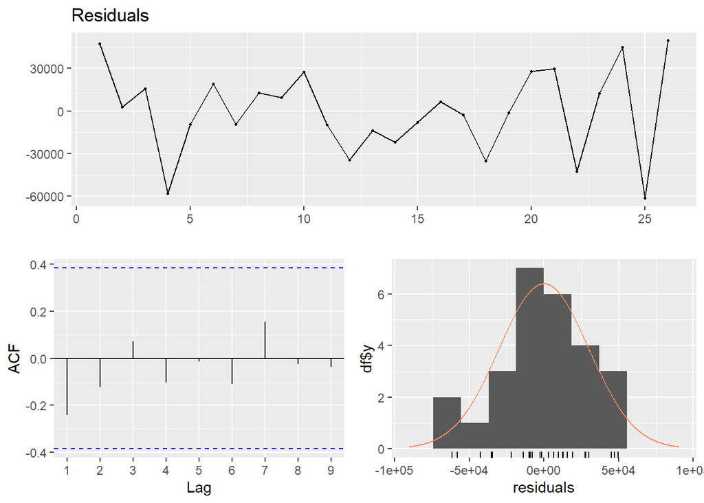

```r
checkresiduals(fit$residuals)
```

As a resulting model we can not observe heavy autocorralation with any lags. Our residuals are distributed normally with mean zero and approximitly constant variance. We can use the model for forecasting.

# Adjusted R-squared: 0.9454

#p-value: 4.152e-12

## Predictions

```r
tmp=copy(hwdata)
tmp[,actual:=Unleaded.Gasoline.Sale..UGS.]
tmp[,predictions:=predict(fit,tmp)]
print(tmp)
```

```
##     Quarter Unleaded.Gasoline.Sale..UGS.   RNUV X..LPG.Vehicles..NLPG.
##  1: 2000_Q1                      1128971 0.0146                 940000
##  2: 2000_Q2                      1199569 0.0205                 941000
##  3: 2000_Q3                      1370167 0.0207                 943500
##  4: 2000_Q4                      1127548 0.0163                 948000
##  5: 2001_Q1                      1033918 0.0071                 950000
##  6: 2001_Q2                      1019754 0.0051                 955000
##  7: 2001_Q3                      1209916 0.0041                 967500
##  8: 2001_Q4                      1002789 0.0048                 990000
##  9: 2002_Q1                       893722 0.0012                1000000
## 10: 2002_Q2                      1027252 0.0032                1001000
## 11: 2002_Q3                      1153265 0.0034                1003500
## 12: 2002_Q4                       991981 0.0044                1008000
## 13: 2003_Q1                       806257 0.0019                1010000
## 14: 2003_Q2                       960556 0.0056                1048000
```

[output cut: 155 more lines]

```r
tmp[ 30, "one_lagged_sales"] = 66210.0
tmp[,predictions2:=predict(fit,tmp)]
tmp[ 31, "one_lagged_sales"] = 1110417.4
tmp[,predictions2:=predict(fit,tmp)]
tmp[ 32, "one_lagged_sales"] = 848645.6
tmp[,predictions2:=predict(fit,tmp)]
```

```r
print(tmp$predictions2)
```

```
##  [1]        NA        NA 1322805.5 1124619.3 1018064.0 1077691.1 1219069.6
##  [8]  983689.5  903056.9 1014510.0 1143640.7  964393.7  816087.5  995111.6
## [15] 1118546.9  955763.9  840310.5  968465.8 1097417.0  889650.1  763910.9
## [22]  862749.6 1011003.6  835936.3  723956.2  832506.0 1008241.7  822203.1
## [29]  673601.0  860180.5        NA        NA
```

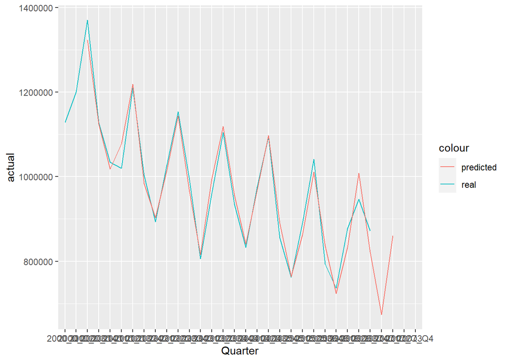

```r
ggplot(tmp ,aes(x=Quarter)) +
  geom_line(aes(y=actual,color='real', group = 1)) +
  geom_line(aes(y=predictions2, color = 'predicted', group = 1) )
```